# HW3

Mert Kaan

1/9/2021

```r
library(knitr)
#library(zoo)
#library(tidyverse)
#library(viridis)
#library(hrbrthemes)
library(plotly)
library(forcats)
library(ggplot2)
library(data.table)
#library(fpp2)
#library(GGally)
library(readxl)
#library(kableExtra)
options(knitr.table.format = "html")
#library(DT)
#library(ggthemes)
library(forecast)
setwd("~/Desktop")
getwd()
```

```
## [1] "/Users/mert/Desktop"
```

Introduction

All of the economic elements, indicators of economical operations of a single country affect and are dependent each other. That means the outcomes of any economical variable is a complex function of some of the other internal and extarnal ecomnomic variables. And in this model, in order to estimate the data, I collect the monthly data of GDP, Interest Rate, Production Index, Unemployment Rate, Expected Inflation and the total number of established companies for I thought this variables may affect the number of liquified company. The idea was; low GDP, high interest rates, low production index, high unemployment rate and high inflation may couse companies to liquidify and since the number of liquified companies is a function of the number of total companies, I used the number of established companies which is a element of the difference of the number of total companies.

The Data, Total Number Liquiified Companies in a Month (2012-2020)

The given data consist of total number of liquified companies in each month between the years 2012 and 2020. As can be seen, it is a highly cyclic data and seems to have a high autocorrelation for yearly period. While examining the data, I assumed that this cyclic patterns may coused by legal issues concerning the authority to liquidify a company in a particular year. Therefore the first thing I have done in order to estimate the data was to take advantage of this pattern by fittig a linear model by sing only month data. The result yielsd as;

```r
all_data <- read_excel("EVDS.xlsx")
all_data <- as.data.table(all_data)

all_data$Date <- as.Date(all_data$Date , format = "%D-%M-%Y" )


all_data[ , Year := year(all_data$Date)]
all_data$Year <- as.factor(all_data$Year)

all_data[ , Month := month(all_data$Date)]
all_data$Month <- as.factor(all_data$Month)

head(all_data)
```

```
##          Date Liquified        GDP Interest Rate Production Index (2015 = 100)
## 1: 2012-01-01      2449 1581479250         11.75                      74.97504
## 2: 2012-02-01      1094 1581479250         14.00                      73.39412
## 3: 2012-03-01       869 1581479250         11.50                      83.76683
## 4: 2012-04-01       882 1581479250         11.00                      80.29805
## 5: 2012-05-01      1123 1581479250         11.35                      86.81221
## 6: 2012-06-01      1311 1581479250         11.50                      86.14740
##    Unemployment Rate Expected Inflation Established (Total) Year Month
## 1:               9.2                9.3                5328 2012     1
## 2:              10.1                9.6                3894 2012     2
## 3:               9.5                9.1                3663 2012     3
## 4:               9.3                8.2                3272 2012     4
## 5:               9.3                7.6                3250 2012     5
## 6:               9.0                7.3                3083 2012     6
```

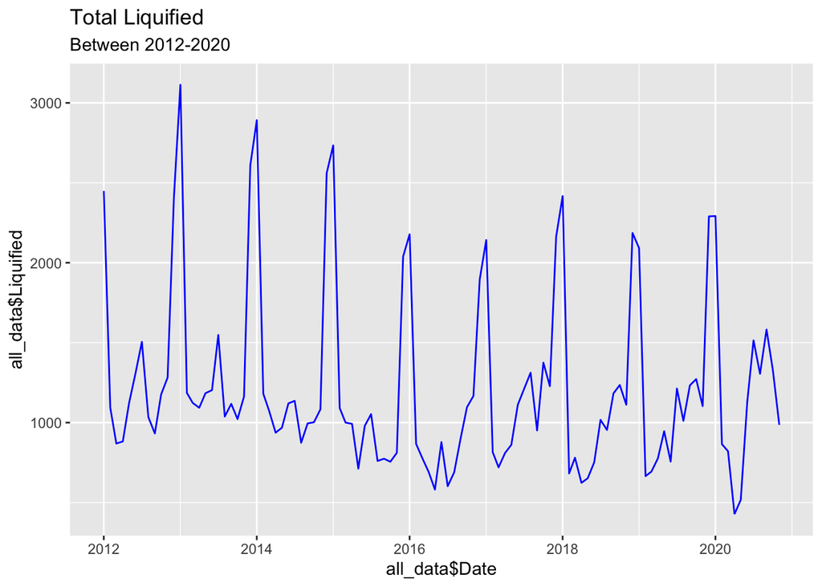

```r
ggplot(all_data, aes(x = all_data$Date , y = all_data$Liquified)) + geom_line( color = "blue") + labs(title="Total Liquified", subtitle="Between 2012-2020")
```

Model 1

The Model 1 yields “231.5” standart error, the month input is clearly have a affect on the data to be estimated. Although the residuals follow an almost normal distribution, they have an evident autocorrelation which states that the model is incomplete.

```r
#1
model1 <- lm(all_data$Liquified~ all_data$Month , data = all_data)
summary(model1)
```

```
##
## Call:
## lm(formula = all_data$Liquified ~ all_data$Month, data = all_data)
##
## Residuals:
##     Min      1Q  Median      3Q     Max
## -597.89 -144.67   -0.89  144.84  634.22
##
## Coefficients:
##                  Estimate Std. Error t value Pr(>|t|)
## (Intercept)       2478.78      77.18  32.117   <2e-16 ***
## all_data$Month2  -1540.33     109.15 -14.112   <2e-16 ***
## all_data$Month3  -1605.56     109.15 -14.710   <2e-16 ***
## all_data$Month4  -1675.33     109.15 -15.349   <2e-16 ***
## all_data$Month5  -1640.56     109.15 -15.030   <2e-16 ***
## all_data$Month6  -1451.89     109.15 -13.302   <2e-16 ***
## all_data$Month7  -1278.89     109.15 -11.717   <2e-16 ***
## all_data$Month8  -1481.33     109.15 -13.572   <2e-16 ***
## all_data$Month9  -1404.33     109.15 -12.866   <2e-16 ***
## all_data$Month10 -1338.33     109.15 -12.261   <2e-16 ***
## all_data$Month11 -1374.89     109.15 -12.596   <2e-16 ***
## all_data$Month12  -209.90     112.51  -1.866   0.0652 .
## ---
## Signif. codes:  0 '***' 0.001 '**' 0.01 '*' 0.05 '.' 0.1 ' ' 1
##
## Residual standard error: 231.5 on 95 degrees of freedom
## Multiple R-squared:  0.8501, Adjusted R-squared:  0.8327
## F-statistic: 48.98 on 11 and 95 DF,  p-value: < 2.2e-16
```

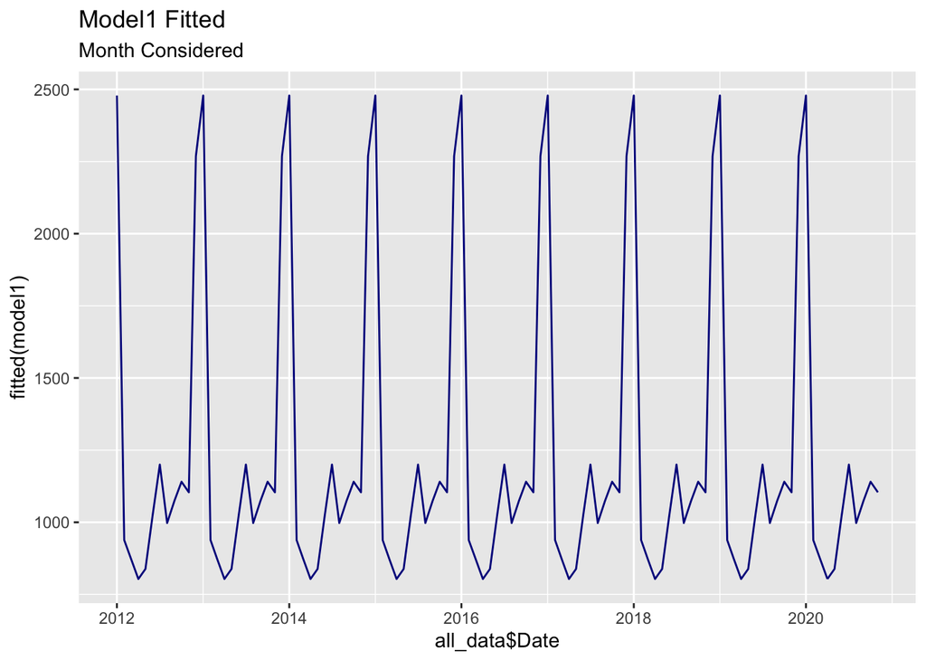

```r
ggplot(all_data, aes(x = all_data$Date , y = fitted(model1))) + geom_line( color = "dark blue") + labs(title="Model1 Fitted", subtitle="Month Considered")
```

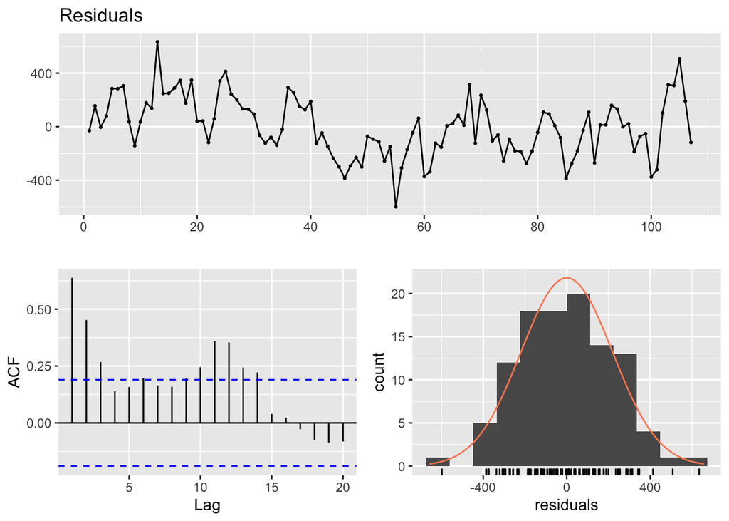

```
##
##  Breusch-Godfrey test for serial correlation of order up to 15
##
## data:  Residuals
## LM test = 57.515, df = 15, p-value = 6.709e-07
```

```r
checkresiduals(model1)
```

```r
all_data[ , residuals1 := residuals(model1)]

#1
```

Finding CrossCorrelations, Model 1

Then, I have plotted the crosscorrelation functions between residuals of model 1 and all of the other possible estimators. I have notice that the highes amount of crosscorrelation was between residuals and Production Index with lag 4 which means the Production Amount of any months seems to affect the total number of liquified companies 4 months later. Then I have shifted the Production Index data by 4 lags to use it as a regressor in my model 2.

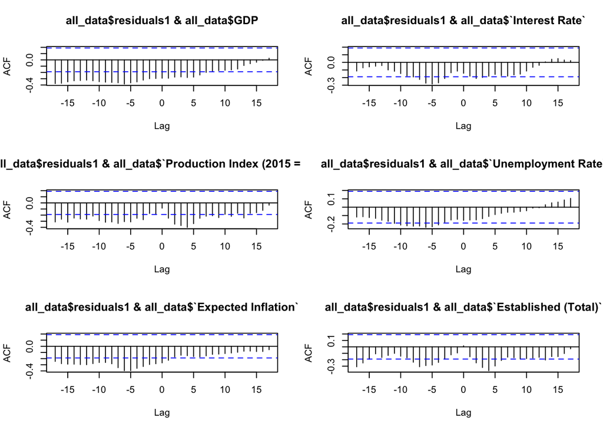

```r
par(mfrow = c(3,2))
ccf(all_data$residuals1, all_data$GDP)
ccf(all_data$residuals1, all_data$`Interest Rate`)
ccf(all_data$residuals1, all_data$`Production Index (2015 = 100)`)
ccf(all_data$residuals1, all_data$`Unemployment Rate`)
ccf(all_data$residuals1, all_data$`Expected Inflation`)
ccf(all_data$residuals1, all_data$`Established (Total)`)
```

```r
all_data <-  all_data[ , Production_l_4 := shift(all_data$`Production Index (2015 = 100)` , n=4L, fill = 74 ) ]

#all_data$Production_l_4 <-all_data$Production_l_4 - mean(all_data$Production_l_4)
```

Model 2

The Model 2 yields “208.3” standart error, which states that the model is improved comparing to previous model and the residuals seems to ddistributed by normal distribution as well. But the residuals seems to have high autocorrelation as well as Model 1.

```r
#2
model2 <- lm(all_data$Liquified~ all_data$Month + all_data$Production_l_4 , data = all_data)
summary(model2)
```

```
##
## Call:
## lm(formula = all_data$Liquified ~ all_data$Month + all_data$Production_l_4,
##     data = all_data)
##
## Residuals:
##     Min      1Q  Median      3Q     Max
## -578.08 -135.39    1.48  134.34  546.36
##
## Coefficients:
##                          Estimate Std. Error t value Pr(>|t|)
## (Intercept)              3185.897    161.897  19.679  < 2e-16 ***
## all_data$Month2         -1513.216     98.356 -15.385  < 2e-16 ***
## all_data$Month3         -1562.832     98.593 -15.851  < 2e-16 ***
## all_data$Month4         -1603.682     99.308 -16.149  < 2e-16 ***
## all_data$Month5         -1688.343     98.692 -17.107  < 2e-16 ***
## all_data$Month6         -1505.773     98.826 -15.237  < 2e-16 ***
## all_data$Month7         -1249.304     98.386 -12.698  < 2e-16 ***
## all_data$Month8         -1494.109     98.231 -15.210  < 2e-16 ***
## all_data$Month9         -1385.686     98.272 -14.101  < 2e-16 ***
## all_data$Month10        -1328.013     98.219 -13.521  < 2e-16 ***
## all_data$Month11        -1351.282     98.317 -13.744  < 2e-16 ***
## all_data$Month12         -237.993    101.385  -2.347    0.021 *
## all_data$Production_l_4    -7.109      1.470  -4.835 5.18e-06 ***
## ---
## Signif. codes:  0 '***' 0.001 '**' 0.01 '*' 0.05 '.' 0.1 ' ' 1
##
## Residual standard error: 208.3 on 94 degrees of freedom
## Multiple R-squared:   0.88,  Adjusted R-squared:  0.8646
## F-statistic: 57.42 on 12 and 94 DF,  p-value: < 2.2e-16
```

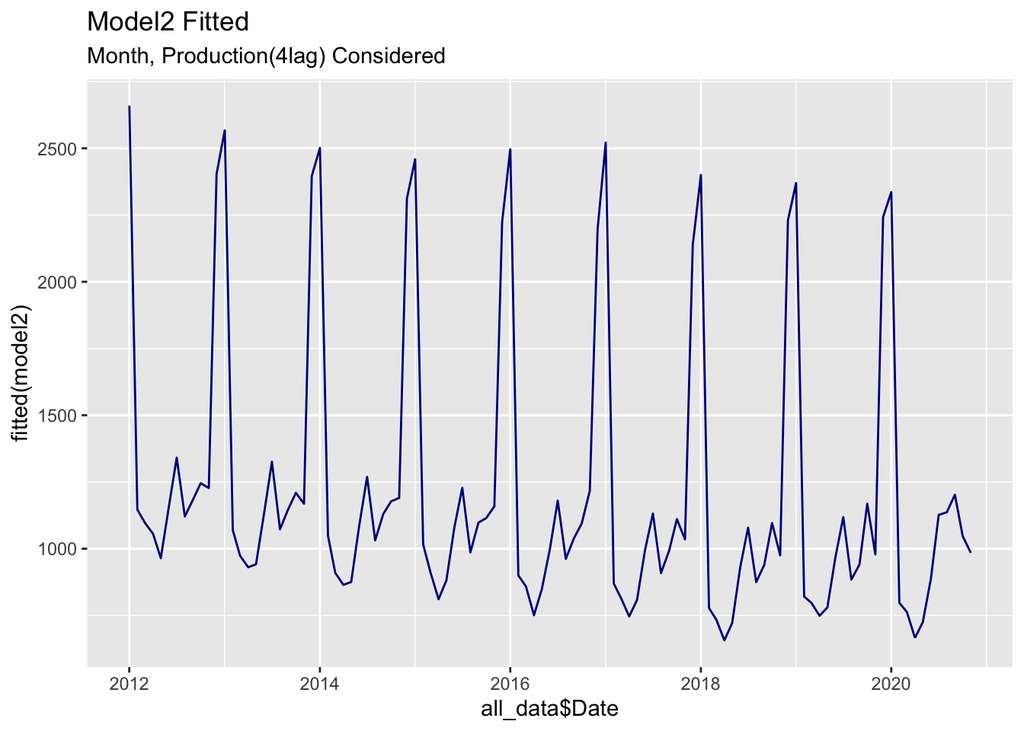

```r
ggplot(all_data, aes(x = all_data$Date , y = fitted(model2))) + geom_line( color = "dark blue") + labs(title="Model2 Fitted", subtitle="Month, Production(4lag) Considered")
```

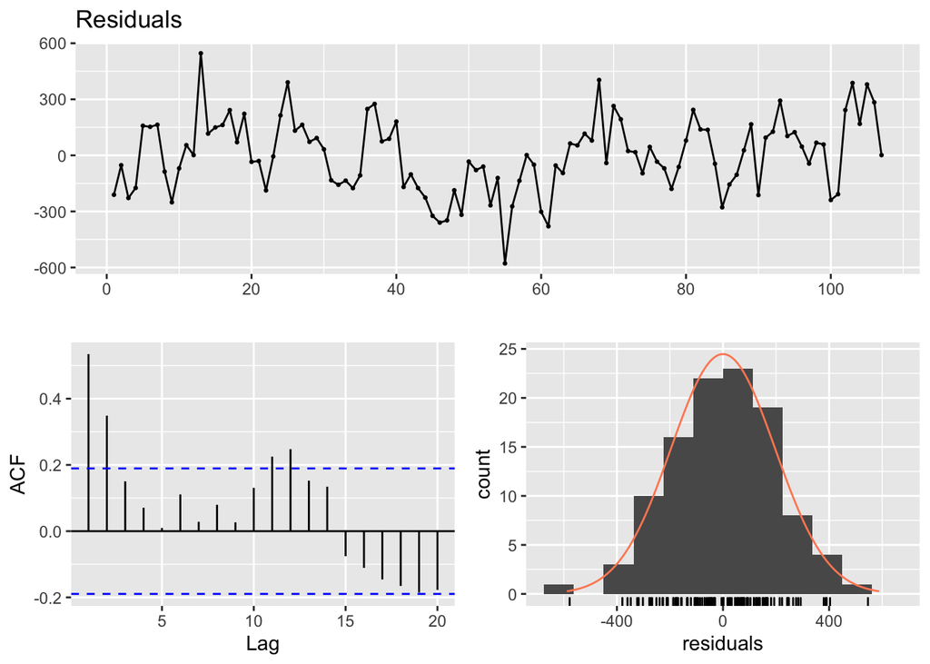

```
##
##  Breusch-Godfrey test for serial correlation of order up to 16
##
## data:  Residuals
## LM test = 43.79, df = 16, p-value = 0.0002122
```

```r
checkresiduals(model2)
```

```r
all_data[ , residuals2 := residuals(model2)]

#2
```

Finding CrossCorrelations, Model 2

Similar to the previous steps, I have plotted ccrosscorrelation plots in order to find a data set to relate with the residuals of Model 2. Then I found that Total Number of Established Companies have high crosscorrelation with total number of Established Companies wiht 0 lag, so I have decided to add this data set as a regressor in the Model 3.

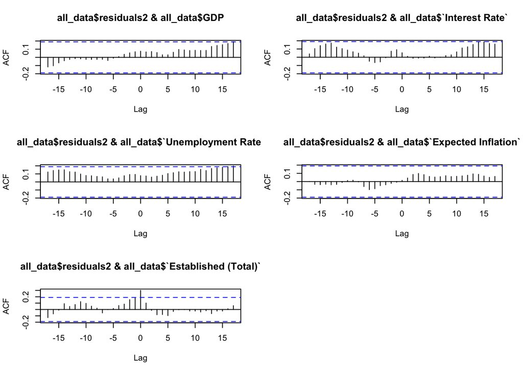

```r
par(mfrow = c(3,2))
ccf(all_data$residuals2, all_data$GDP)
ccf(all_data$residuals2, all_data$`Interest Rate`)
ccf(all_data$residuals2, all_data$`Unemployment Rate`)
ccf(all_data$residuals2, all_data$`Expected Inflation`)
ccf(all_data$residuals2, all_data$`Established (Total)`)
```

Model 3

```r
#3
model3 <- lm(all_data$Liquified~ all_data$Month + all_data$Production_l_4 + all_data$`Established (Total)` , data = all_data)
summary(model3)
```

```
##
## Call:
## lm(formula = all_data$Liquified ~ all_data$Month + all_data$Production_l_4 +
##     all_data$`Established (Total)`, data = all_data)
##
## Residuals:
##     Min      1Q  Median      3Q     Max
## -450.29 -121.22    2.96  123.69  641.34
##
## Coefficients:
##                                  Estimate Std. Error t value Pr(>|t|)
## (Intercept)                     3.227e+03  1.504e+02  21.462  < 2e-16 ***
## all_data$Month2                -1.441e+03  9.286e+01 -15.517  < 2e-16 ***
## all_data$Month3                -1.493e+03  9.295e+01 -16.065  < 2e-16 ***
## all_data$Month4                -1.482e+03  9.682e+01 -15.302  < 2e-16 ***
## all_data$Month5                -1.629e+03  9.263e+01 -17.581  < 2e-16 ***
## all_data$Month6                -1.455e+03  9.242e+01 -15.747  < 2e-16 ***
## all_data$Month7                -1.148e+03  9.454e+01 -12.140  < 2e-16 ***
## all_data$Month8                -1.402e+03  9.381e+01 -14.946  < 2e-16 ***
## all_data$Month9                -1.303e+03  9.330e+01 -13.967  < 2e-16 ***
## all_data$Month10               -1.270e+03  9.211e+01 -13.792  < 2e-16 ***
## all_data$Month11               -1.288e+03  9.243e+01 -13.934  < 2e-16 ***
## all_data$Month12               -1.757e+02  9.519e+01  -1.846 0.068055 .
## all_data$Production_l_4        -1.116e+01  1.688e+00  -6.607 2.41e-09 ***
## all_data$`Established (Total)`  5.104e-02  1.257e-02   4.059 0.000103 ***
## ---
## Signif. codes:  0 '***' 0.001 '**' 0.01 '*' 0.05 '.' 0.1 ' ' 1
##
## Residual standard error: 193 on 93 degrees of freedom
## Multiple R-squared:  0.898,  Adjusted R-squared:  0.8838
## F-statistic:    63 on 13 and 93 DF,  p-value: < 2.2e-16
```

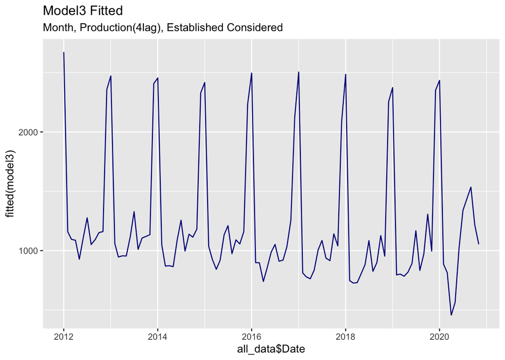

```r
ggplot(all_data, aes(x = all_data$Date , y = fitted(model3))) + geom_line( color = "dark blue") + labs(title="Model3 Fitted", subtitle="Month, Production(4lag), Established Considered")
```

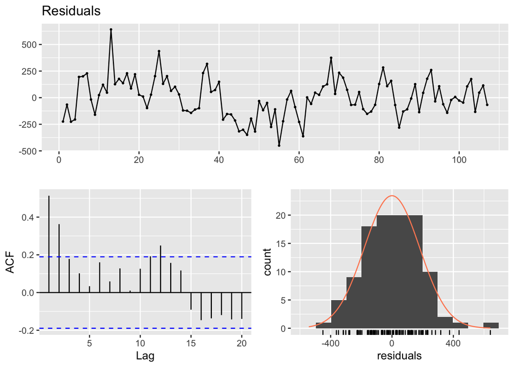

```
##
##  Breusch-Godfrey test for serial correlation of order up to 17
##
## data:  Residuals
## LM test = 44.516, df = 17, p-value = 0.0002874
```

```r
checkresiduals(model3)
```

```r
all_data[ , residuals3 := residuals(model3)]

#3
```

Finding CrossCorrelations, Model 3

In order to find the most suitable dataset to explain autocorrelated residuals obtained from Model 3, I have plotted crosscorrelation plots with the candidate datasets and could not find any significant autocorrelation. Therefore, since the last residuals obtained have a high 1 lag autocorrelation, states that last month’s data have affect of current month’s data which could not be explained by the regressors I have used, I have added previous month’s data into the regression model in the Model 4.

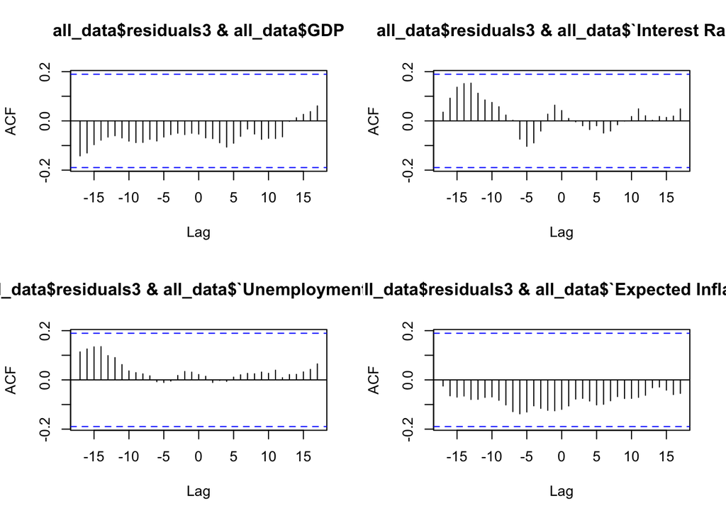

```r
par(mfrow = c(2,2))
ccf(all_data$residuals3, all_data$GDP)
ccf(all_data$residuals3, all_data$`Interest Rate`)
ccf(all_data$residuals3, all_data$`Unemployment Rate`)
ccf(all_data$residuals3, all_data$`Expected Inflation`)
```

```r
all_data <-  all_data[ , Previous := shift( x = all_data$Liquified , n = 1L , fill = 2270 ) ]
```

Model 4

```r
#4

model4<<- lm(all_data$Liquified~ all_data$Month + all_data$Production_l_4 + all_data$`Established (Total)` + all_data$Previous , data = all_data)
summary(model4)
```

```
##
## Call:
## lm(formula = all_data$Liquified ~ all_data$Month + all_data$Production_l_4 +
##     all_data$`Established (Total)` + all_data$Previous, data = all_data)
##
## Residuals:
##     Min      1Q  Median      3Q     Max
## -416.93 -111.94    2.61  100.74  589.24
##
## Coefficients:
##                                  Estimate Std. Error t value Pr(>|t|)
## (Intercept)                     1.781e+03  2.682e+02   6.639 2.16e-09 ***
## all_data$Month2                -1.575e+03  8.165e+01 -19.285  < 2e-16 ***
## all_data$Month3                -8.714e+02  1.285e+02  -6.784 1.11e-09 ***
## all_data$Month4                -8.532e+02  1.313e+02  -6.498 4.12e-09 ***
## all_data$Month5                -8.973e+02  1.428e+02  -6.282 1.09e-08 ***
## all_data$Month6                -7.363e+02  1.411e+02  -5.219 1.11e-06 ***
## all_data$Month7                -5.717e+02  1.235e+02  -4.628 1.20e-05 ***
## all_data$Month8                -8.904e+02  1.153e+02  -7.723 1.35e-11 ***
## all_data$Month9                -7.030e+02  1.259e+02  -5.585 2.35e-07 ***
## all_data$Month10               -6.985e+02  1.217e+02  -5.741 1.20e-07 ***
## all_data$Month11               -7.560e+02  1.169e+02  -6.465 4.78e-09 ***
## all_data$Month12                3.903e+02  1.226e+02   3.182 0.001992 **
## all_data$Production_l_4        -7.001e+00  1.583e+00  -4.423 2.67e-05 ***
## all_data$`Established (Total)`  3.847e-02  1.085e-02   3.545 0.000619 ***
## all_data$Previous               4.945e-01  8.070e-02   6.127 2.19e-08 ***
## ---
## Signif. codes:  0 '***' 0.001 '**' 0.01 '*' 0.05 '.' 0.1 ' ' 1
##
## Residual standard error: 163.5 on 92 degrees of freedom
## Multiple R-squared:  0.9276, Adjusted R-squared:  0.9166
## F-statistic: 84.16 on 14 and 92 DF,  p-value: < 2.2e-16
```

[figure not shown]

```r
ggplot(all_data, aes(x = all_data$Date , y = fitted(model4))) + geom_line( color = "dark blue") + labs(title="Model3 Fitted", subtitle="Month, Production(4lag), Established, Liquiied(1lag) Considered")
```

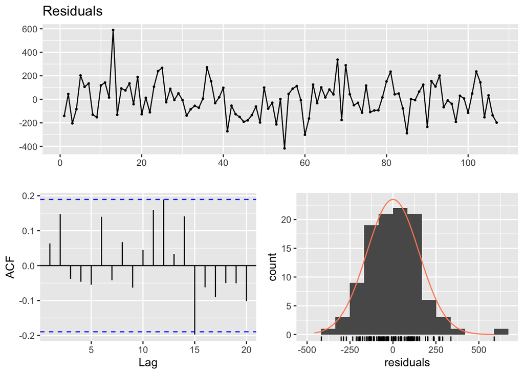

```
##
##  Breusch-Godfrey test for serial correlation of order up to 18
##
## data:  Residuals
## LM test = 21.867, df = 18, p-value = 0.238
```

```r
checkresiduals(model4)
```

```r
all_data[ , residuals4 := residuals(model4)]



#4
```

Finding CrossCorrelations, Model 4

To statically inspect the relation between the crosscorrelation between residuals and remaining candidate regressors, I plotted crosscorrelation plots just like the previous steps. And the most prominent relation is between residuals and Total number of Established companies with 1 lag, which sounds sensible since some of the recently established companies may liquidify after just one month. So I have added this 1 lagged information as a regressor to the model and have built Model 5.

```r
par(mfrow = c(3,2))
ccf(all_data$residuals4, all_data$GDP)
ccf(all_data$residuals4, all_data$`Interest Rate`)
ccf(all_data$residuals4, all_data$`Unemployment Rate`)
ccf(all_data$residuals4, all_data$`Expected Inflation`)
ccf(all_data$residuals4, all_data$`Established (Total)`)


all_data <-  all_data[ , Established_l_1 := shift( x = all_data$`Established (Total)` , n = 1L , fill = 5000 ) ]
```

[figure not shown]

Model 5

```r
#5

model5<<- lm(all_data$Liquified~ all_data$Month + all_data$Production_l_4 + all_data$`Established (Total)` + all_data$Previous + all_data$Established_l_1 , data = all_data)
summary(model5)
```

```
##
## Call:
## lm(formula = all_data$Liquified ~ all_data$Month + all_data$Production_l_4 +
##     all_data$`Established (Total)` + all_data$Previous + all_data$Established_l_1,
##     data = all_data)
##
## Residuals:
##     Min      1Q  Median      3Q     Max
## -314.74  -80.53   -9.08   91.05  569.69
##
## Coefficients:
##                                  Estimate Std. Error t value Pr(>|t|)
## (Intercept)                     1.356e+03  2.583e+02   5.251 9.86e-07 ***
## all_data$Month2                -1.457e+03  7.781e+01 -18.721  < 2e-16 ***
## all_data$Month3                -6.732e+02  1.233e+02  -5.458 4.13e-07 ***
## all_data$Month4                -6.135e+02  1.290e+02  -4.756 7.38e-06 ***
## all_data$Month5                -6.509e+02  1.391e+02  -4.678 1.00e-05 ***
## all_data$Month6                -5.034e+02  1.366e+02  -3.686 0.000387 ***
## all_data$Month7                -3.774e+02  1.189e+02  -3.175 0.002044 **
## all_data$Month8                -6.932e+02  1.122e+02  -6.181 1.77e-08 ***
## all_data$Month9                -5.354e+02  1.190e+02  -4.498 2.02e-05 ***
## all_data$Month10               -5.179e+02  1.163e+02  -4.453 2.40e-05 ***
## all_data$Month11               -5.628e+02  1.132e+02  -4.972 3.11e-06 ***
## all_data$Month12                6.069e+02  1.199e+02   5.064 2.13e-06 ***
## all_data$Production_l_4        -4.587e+00  1.518e+00  -3.022 0.003261 **
## all_data$`Established (Total)`  8.002e-02  1.319e-02   6.065 2.97e-08 ***
## all_data$Previous               6.033e-01  7.640e-02   7.897 6.26e-12 ***
## all_data$Established_l_1       -6.502e-02  1.384e-02  -4.697 9.32e-06 ***
## ---
## Signif. codes:  0 '***' 0.001 '**' 0.01 '*' 0.05 '.' 0.1 ' ' 1
##
## Residual standard error: 147.5 on 91 degrees of freedom
## Multiple R-squared:  0.9417, Adjusted R-squared:  0.9321
## F-statistic:    98 on 15 and 91 DF,  p-value: < 2.2e-16
```

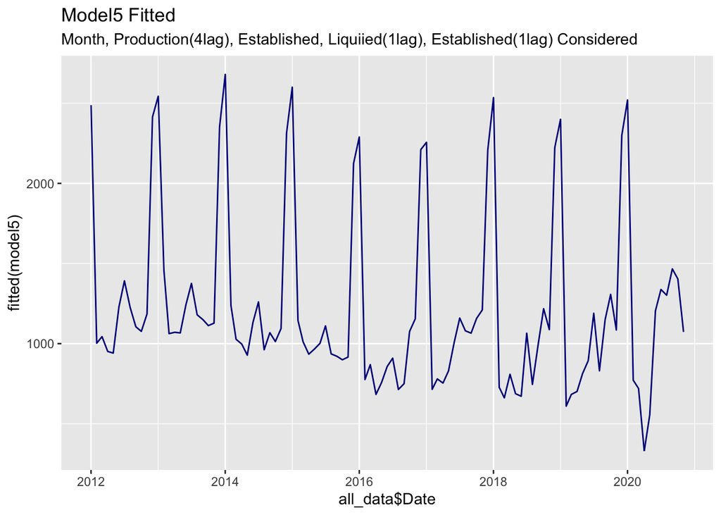

```r
ggplot(all_data, aes(x = all_data$Date , y = fitted(model5))) + geom_line( color = "dark blue") + labs(title="Model5 Fitted", subtitle="Month, Production(4lag), Established, Liquiied(1lag), Established(1lag) Considered")
```

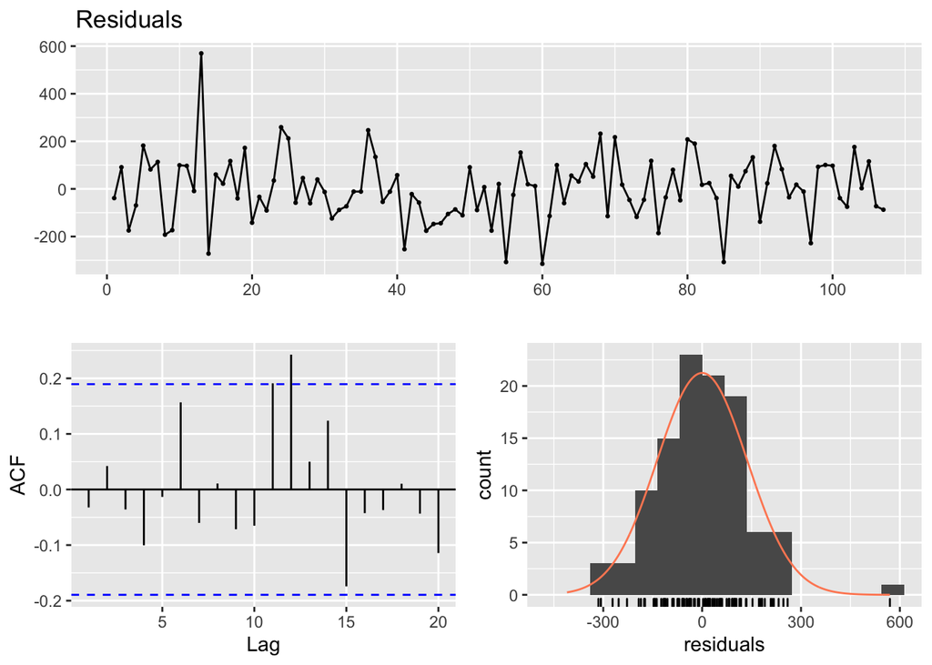

```
##
##  Breusch-Godfrey test for serial correlation of order up to 19
##
## data:  Residuals
## LM test = 21.184, df = 19, p-value = 0.3267
```

```r
checkresiduals(model5)
```

```r
all_data[ , residuals5 := residuals(model5)]

#5
```

Visual Examination of Model 5 vs Actual Data

Below, I have plotted two graphs to examine performance of the final model. Residuals seem to randomly scattered for every observation except for the first months of years 2013, 2014 and 2015 where model underpredicts. But I could not find valid reason for this observations to have larger value or being outlyer, therefore I choose to not add an external or internal regressor to explain this behaivour in order to avoid overfitting.

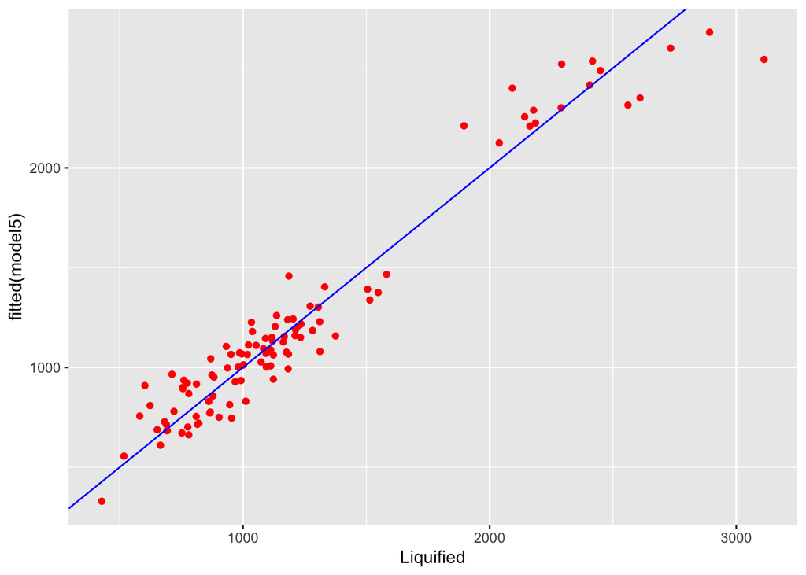

```r
all_data %>%
  ggplot(aes(x= Liquified, y=fitted(model5))) +
  geom_point( color = "red") +
  geom_abline(slope=1, intercept=0 , color  = "blue")
```

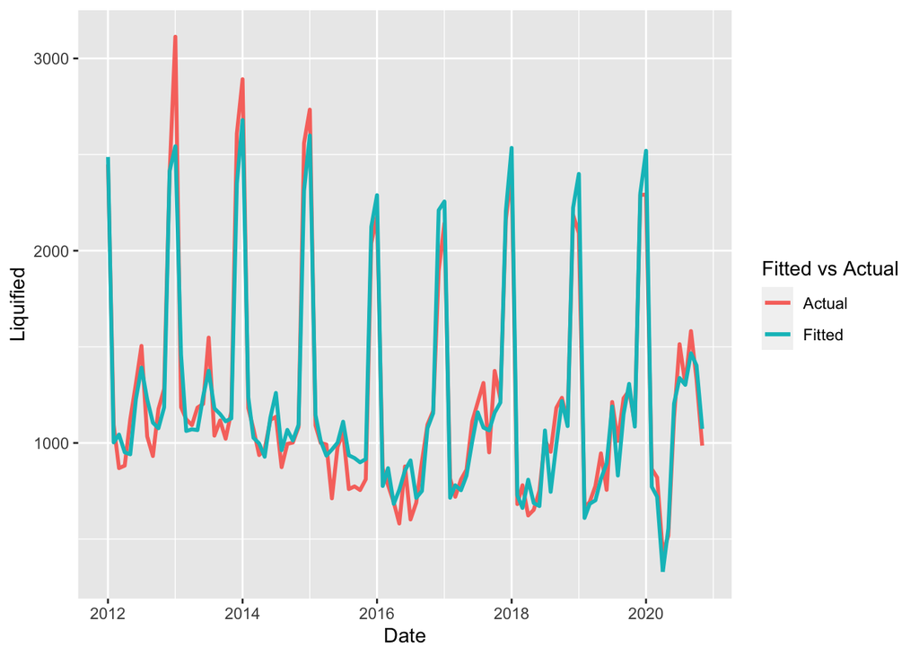

```r
all_data[ , fitted := fitted(model5)]

ggplot()+
    geom_line(data=all_data , aes(y= Liquified  ,x= Date , colour="blue"),size=1 )+
    geom_line(data=all_data , aes(y=  fitted ,x= Date , colour="orange"),size=1) +
    scale_color_discrete(name = "Fitted vs Actual", labels = c("Actual", "Fitted"))
```

Conclusion and Prediction

To conclude, while trying to fit a model for my Total Number of Monthly Liquified Company data, I collected some datasets which I thought related to the data I would like to predict. The method was a basic constructive algorithm which decides what dataset to add by checking crosscorrelations with previous models’ residuals.

```r
summary(model5)
```

```
##
## Call:
## lm(formula = all_data$Liquified ~ all_data$Month + all_data$Production_l_4 +
##     all_data$`Established (Total)` + all_data$Previous + all_data$Established_l_1,
##     data = all_data)
##
## Residuals:
##     Min      1Q  Median      3Q     Max
## -314.74  -80.53   -9.08   91.05  569.69
##
## Coefficients:
##                                  Estimate Std. Error t value Pr(>|t|)
## (Intercept)                     1.356e+03  2.583e+02   5.251 9.86e-07 ***
## all_data$Month2                -1.457e+03  7.781e+01 -18.721  < 2e-16 ***
## all_data$Month3                -6.732e+02  1.233e+02  -5.458 4.13e-07 ***
## all_data$Month4                -6.135e+02  1.290e+02  -4.756 7.38e-06 ***
## all_data$Month5                -6.509e+02  1.391e+02  -4.678 1.00e-05 ***
## all_data$Month6                -5.034e+02  1.366e+02  -3.686 0.000387 ***
## all_data$Month7                -3.774e+02  1.189e+02  -3.175 0.002044 **
## all_data$Month8                -6.932e+02  1.122e+02  -6.181 1.77e-08 ***
## all_data$Month9                -5.354e+02  1.190e+02  -4.498 2.02e-05 ***
## all_data$Month10               -5.179e+02  1.163e+02  -4.453 2.40e-05 ***
## all_data$Month11               -5.628e+02  1.132e+02  -4.972 3.11e-06 ***
## all_data$Month12                6.069e+02  1.199e+02   5.064 2.13e-06 ***
## all_data$Production_l_4        -4.587e+00  1.518e+00  -3.022 0.003261 **
## all_data$`Established (Total)`  8.002e-02  1.319e-02   6.065 2.97e-08 ***
## all_data$Previous               6.033e-01  7.640e-02   7.897 6.26e-12 ***
## all_data$Established_l_1       -6.502e-02  1.384e-02  -4.697 9.32e-06 ***
## ---
## Signif. codes:  0 '***' 0.001 '**' 0.01 '*' 0.05 '.' 0.1 ' ' 1
##
## Residual standard error: 147.5 on 91 degrees of freedom
## Multiple R-squared:  0.9417, Adjusted R-squared:  0.9321
## F-statistic:    98 on 15 and 91 DF,  p-value: < 2.2e-16
```

References https://evds2.tcmb.gov.tr